# Project One: Wasted Potential

Sneha, RyeAnne, Ben, Yuqi

11 March 2020

#### ______________________________________________________________________________

#### **Summary of The Dataset**

The dataset of choice for Project One was originally constructed by the World Health Organization (WHO) to track the health status of 193 countries across the world. The question we sought to answer is as follows:

**What factors affect life expectancy in individuals across the world?**

The dataset includes a variety of factors that contribute to the overall health status of a country. We wanted to know what effect these factors had specifically on life expectancy. An explanation of the different factors in this dataset are as follows:

• **Country:** Country

• **Year:** Year

• **Status:** Developed or Developing status

• **Life expectancy:** Life Expectancy in age

• **Adult Mortality:** Adult Mortality Rates of both sexes (probability of dying between 15 and 60 years per 1000 population)

• **Infant deaths:** Number of Infant Deaths per 1000 population

• **Alcohol:** Alcohol, recorded per capita (15+) consumption (in litres of pure alcohol)

• **Percentage expenditure:** Expenditure on health as a percentage of GDP per capita(%)

• **Hepatitis B:** HepB immunization coverage among 1-year-olds (%)

• **Measles:** Number of reported measles cases per 1000 population

• **BMI:** Average Body Mass Index of entire population

• **Under-five deaths:** Number of under-five deaths per 1000 population

• **Polio:** Pol3 immunization coverage among 1-year-olds (%)

• **Total expenditure:** General government expenditure on health as a percentage of total government expenditure (%)

• **Diphtheria:** DTP3 immunization coverage among 1-year-olds (%)

• **HIV/AIDS:** Deaths per 1 000 live births HIV/AIDS (0-4 years)

• **GDP:** Gross Domestic Product per capita (in USD)

• **Population:** Population of the country

• **Thinness 10-19 years:** Prevalence of thinness among children/adolescents, age 10 - 19(%)

• **Thinness 5-9 years:** Prevalence of thinness among children, age 5 to 9 (%)

• **Income comp of resources:** HDI in terms of income composition of resources (index ranging from 0 to 1)

• **Schooling:** Number of years of Schooling (years)

Data Source: [Kaggle](https://www.kaggle.com/kumarajarshi/life-expectancy-who)

#### ______________________________________________________________________________

### Life expectancy distributions

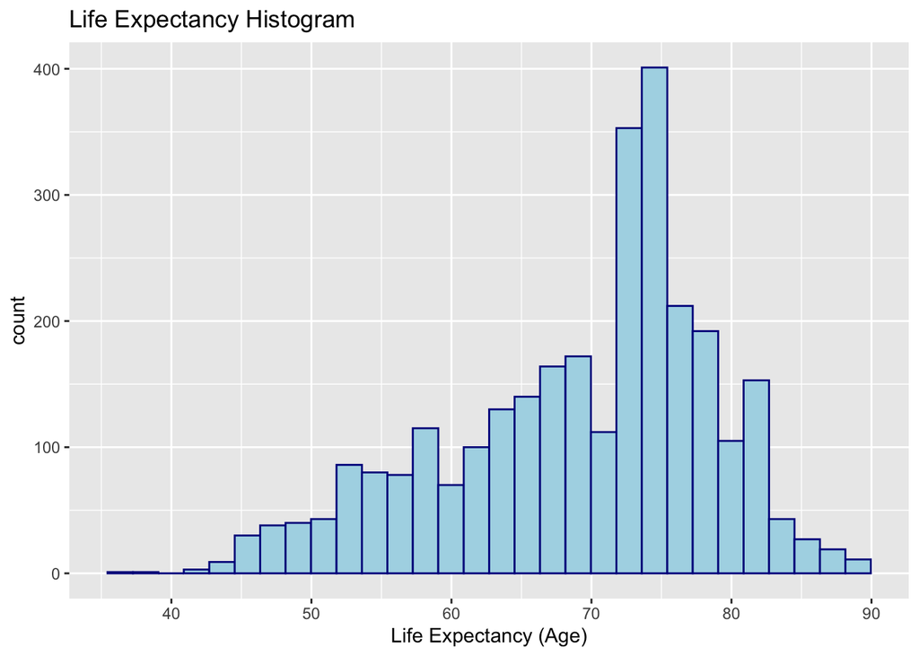

```r
life2 <- na.omit(life) #omit missing values

loadPkg("ggplot2")
ggplot(life, aes(x=Life.expectancy) )+
  geom_histogram(color="darkblue",fill="lightblue")+
  ggtitle("Life Expectancy Histogram")+
  xlab("Life Expectancy (Age)")
```

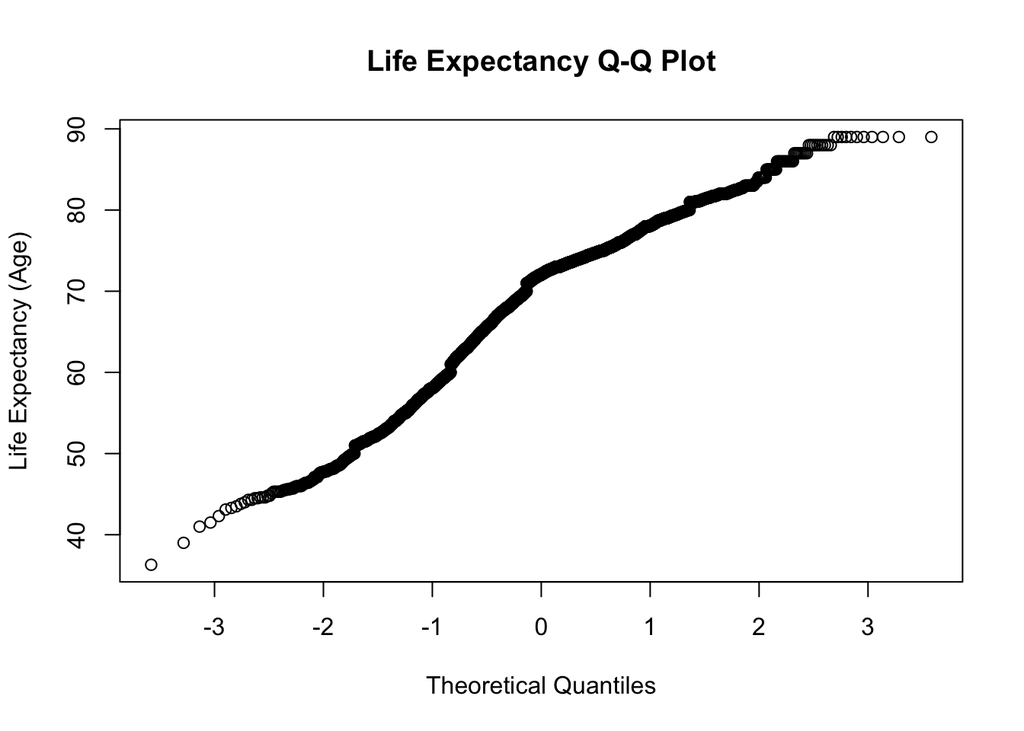

```r
qqnorm(life$Life.expectancy, main="Life Expectancy Q-Q Plot", ylab="Life Expectancy (Age)")
```

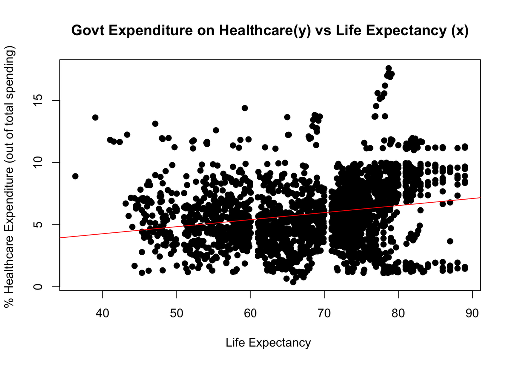

```r
#ggplot(life2, aes(x=Total.expenditure, y=Life.expectancy, fill=Total.expenditure, group = 1)) + geom_boxplot() + scale_fill_brewer(palette="Spectral") + ggtitle("Life Expectancy vs. Total Expenditure") + ylab("Life Expectancy") + xlab("Total Expenditure ($)")

plot(life$Life.expectancy, life$Total.expenditure, main=" Govt Expenditure on Healthcare(y) vs Life Expectancy (x) ",
   xlab="Life Expectancy ", ylab="% Healthcare Expenditure (out of total spending) ", pch=19) +
  abline(lm(life$Total.expenditure~life$Life.expectancy), col="red") # regression line (y~x)
```

### Descriptive Statistics

```r
#sapply(life, mean, na.rm=TRUE) # excluding missing values
#sapply(life, sd)
summary(life)
```

[output not shown]

### Correlation

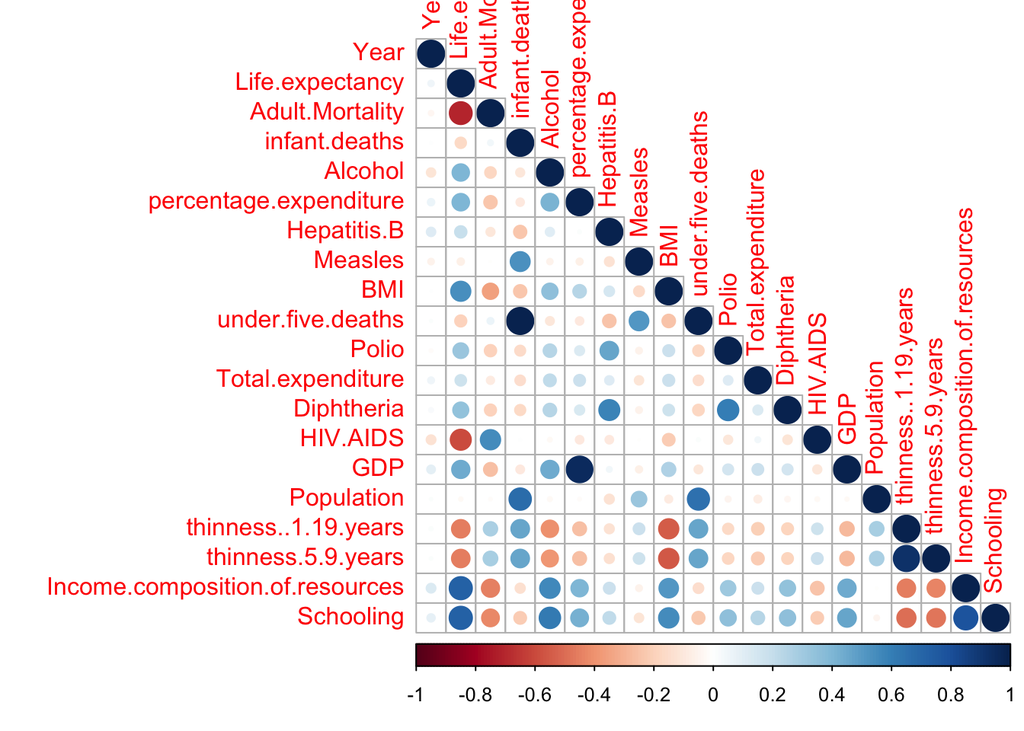

```r
library(dplyr)
sapply(life, class) #look at the class of each variables
life_nofactor = select(life, -c(Country, Status)) #remove the factor variables
cor_life=cor(na.omit(life_nofactor)) #create correlation matrix
library(corrplot)
corrplot(cor_life, type="lower") #plot correlation matrix
```

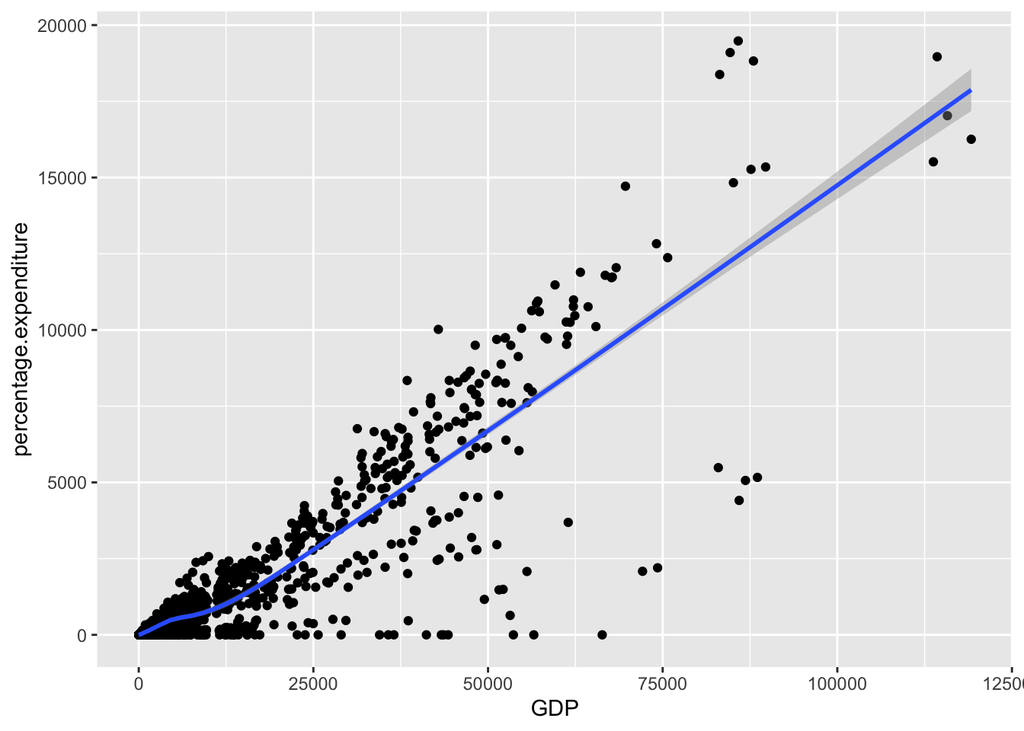

```r
ggplot(life, aes(x=GDP, y=percentage.expenditure)) +
  geom_point() +
  geom_smooth()
```

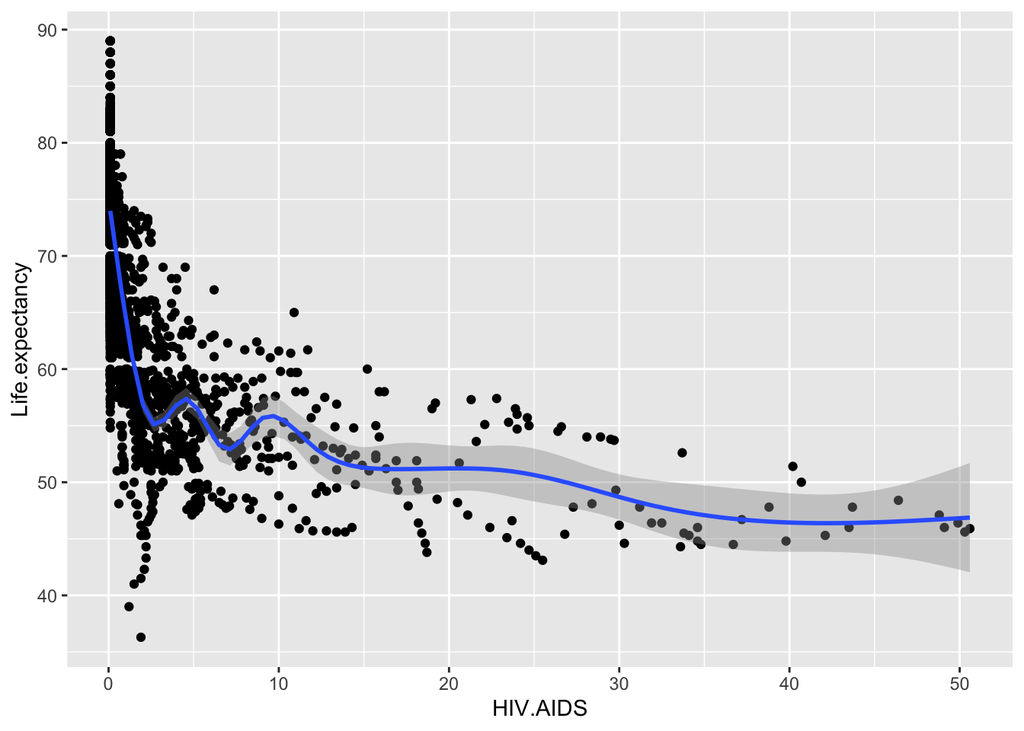

```r
ggplot(life, aes(x=HIV.AIDS, y=Life.expectancy)) +
  geom_point() +
  geom_smooth()
```

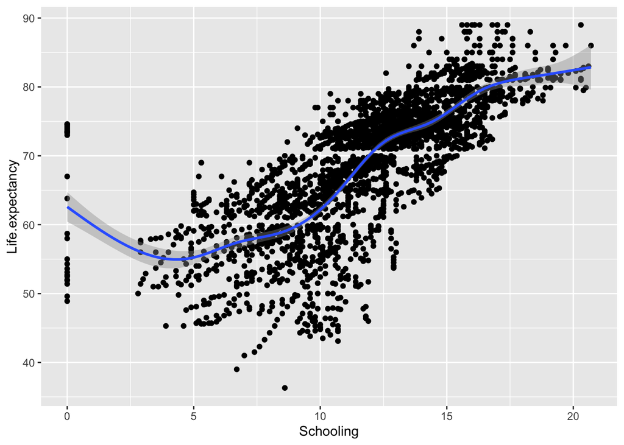

```r
ggplot(life, aes(x=Schooling, y=Life.expectancy)) +
  geom_point() +
  geom_smooth()
```

### Associatin of Life Expectancy with Factor Variables

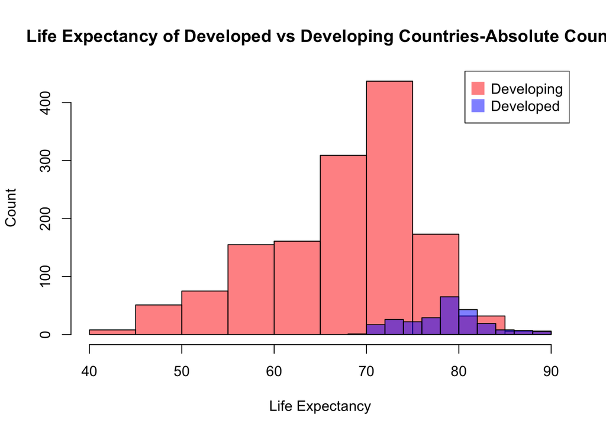

```r
#summary(life)
life_developed=na.omit(subset(life, Status=='Developed')) #subset of countries that are Developed
life_developing=na.omit(subset(life, Status=='Developing')) #subset of countries that are Developing

#Life expectancy of Developed/Developing are different as p<<0.05
mean_life_developed = mean(life_developed$Life.expectancy)
mean_life_developing = mean(life_developing$Life.expectancy)
t_life_developed = t.test(x=life_developed$Life.expectancy, conf.level=0.95 )
t_life_developing= t.test(x=life_developing$Life.expectancy, conf.level=0.95 )
t_life_developed$conf.int
t_life_developing$conf.int
mean_life_developed
mean_life_developing

#Use Chi-squared test to determine if Life Expectancy is independent of Developed/Developing
contable = table(life$Life.expectancy, life$Status)
chitest = chisq.test(contable)
chitest  #Not independent as p<<0.05

#make overlaying histograms of the two subgroups aes(x = rank, y = gpa, fill = admit)
# First distribution
hist(life_developing$Life.expectancy, col=rgb(1,0,0,0.5), xlab="Life Expectancy",
     ylab="Count", main="Life Expectancy of Developed vs Developing Countries-Absolute Count" )
# Second with add=T to plot on top
hist(life_developed$Life.expectancy, col=rgb(0,0,1,0.5), add=T)
# Add legend
legend("topright", legend=c("Developing","Developed"), col=c(rgb(1,0,0,0.5),
     rgb(0,0,1,0.5)), pt.cex=2, pch=15 )
```

[output not shown]

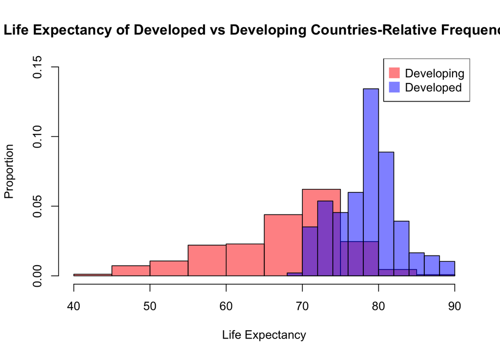

```r
#Histogram Plot of Developed vs Developing using relative frequency
#make overlaying histograms of the two subgroups aes(x = rank, y = gpa, fill = admit)
# First distribution
hist(life_developing$Life.expectancy, col=rgb(1,0,0,0.5), xlab="Life Expectancy",
     ylab="Proportion", main="Life Expectancy of Developed vs Developing Countries-Relative Frequencies" , freq=F,
     ylim = c(0,0.15))
# Second with add=T to plot on top
hist(life_developed$Life.expectancy, col=rgb(0,0,1,0.5), add=T, freq=F)
# Add legend
legend("topright", legend=c("Developing","Developed"), col=c(rgb(1,0,0,0.5),
     rgb(0,0,1,0.5)), pt.cex=2, pch=15 )
```

```r
#Variables most highly correlated to life expectacy were Income.composition.of.resources and Schooling. Though BMI and Aids had highish correlations. Adult mortality was highly correlated with life expectancy, but the reasons are obvious, so they will not be evaluated here.
#These all compare the differences in means between the developing and developed countries
developed_income= mean(life_developed$Income.composition.of.resources)
developing_income=mean(life_developing$Income.composition.of.resources)
developed_school=mean(life_developed$Schooling)
developing_school=mean(life_developing$Schooling)
developed_BMI=mean(life_developed$BMI)
developing_BMI=mean(life_developing$BMI)
developed_AIDS=mean(life_developed$HIV.AIDS)
developing_AIDS=mean(life_developing$HIV.AIDS)

developed_income
developing_income
developed_school
developing_school
developed_BMI
developing_BMI
developed_AIDS
developing_AIDS
```

[output not shown]

### Is Life Expectancy Increasing?

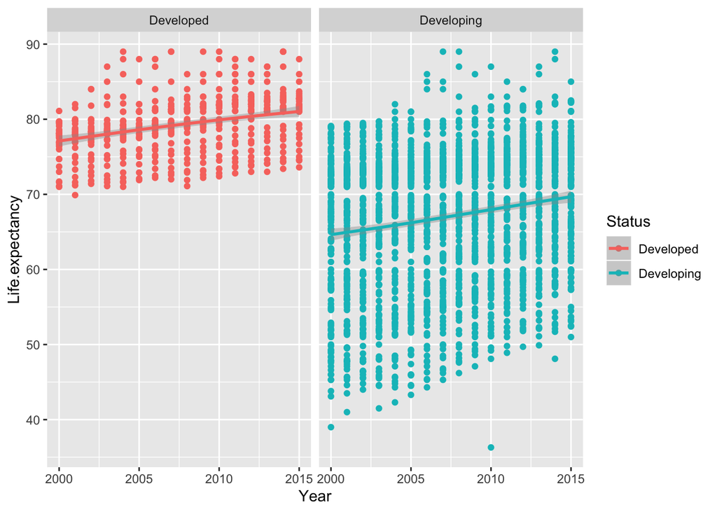

```r
ggplot(life, aes(x=Year, y=Life.expectancy, col=Status))+
  geom_point() +
  geom_smooth() +
  facet_wrap(~Status)
```